# Data Analysis

# Import libraries and methods

```r
library(tidyverse)
library(ggplot2)
library(knitr)
library(testthat)
source("bootstrap.R")
```

This vignette demonstrates how to use the function within the ‘STA380GroupProject’ package for simulating sample distributions with the two-sample bootstrap method:

- two-sample bootstrap ’STA380GroupProject::two_sample_bootstrap()

The following examples are for generating 1000 bootstrap iterations to construct sampling distributions for the difference in means across two biological categories. We investigate:

- Sexual variation: Computing mean snout-vent lengths(mm) between males and females
- Thermoregulation: Comparing mean body temperatures (Celsius) between gravid and non-gravid females

# Load Data

```r
lizard_data <- read.csv("data.csv",
 fileEncoding = "latin1")

# Inspect data
print(head(lizard_data, 5))
```

```
##   ID Snout.vent.length..mm. Sex Reproductive.status Body.temperature...C.
## 1  1                     60   M                                      37.8
## 2  1                     60   M                                      35.3
## 3  1                     60   M                                      37.5
## 4  1                     60   M                                      33.9
## 5  1                     60   M                                      36.0
```

# Clean up data

Before the dataset can be analyzed, it must be cleaned to ensure consistency. We standardize variable names and remove observations with missing values for sex, snout-vent length, or body temperature to ensure our bootstrap iterations are based on complete cases.

```r
#Clean names replace . with _ between word spaces,
#remove white spaces and lowercase
colnames(lizard_data) <- tolower(gsub(" ", "_", trimws(gsub("\\.+", " ", colnames(lizard_data)))))

#Print the first 10 entries of dataset
print(head(lizard_data, 10))
```

```
##    id snout_vent_length_mm sex reproductive_status body_temperature_c
## 1   1                   60   M                                   37.8
## 2   1                   60   M                                   35.3
## 3   1                   60   M                                   37.5
## 4   1                   60   M                                   33.9
## 5   1                   60   M                                   36.0
## 6   1                   60   M                                   33.4
## 7   1                   60   M                                   34.6
## 8   1                   60   M                                   36.6
## 9   1                   60   M                                   36.7
## 10  1                   60   M                                   35.4
```

```r
#Print Size of data set
print(dim(lizard_data))
```

```
## [1] 808   5
```

```r
#Remove rows with missing sex, snout_vent_length_mm or body_temperature_c
clean_data <- lizard_data %>%
    filter(
    !is.na(sex),
    !is.na(snout_vent_length_mm),
    !is.na(body_temperature_c))

#Print the first 5 entries of dataset
print(head(clean_data, 5))
```

```
##   id snout_vent_length_mm sex reproductive_status body_temperature_c
## 1  1                   60   M                                   37.8
## 2  1                   60   M                                   35.3
## 3  1                   60   M                                   37.5
## 4  1                   60   M                                   33.9
## 5  1                   60   M                                   36.0
```

```r
#Print Size of data set
print(dim(clean_data))
```

```
## [1] 808   5
```

# Extract data

```r
# Snout Length values
male_snout_len <- clean_data[    # Male snout length
    clean_data["sex"] == "M",
    "snout_vent_length_mm"]

female_snout_len <- clean_data[  # Female snout length
    clean_data["sex"] == "F",
    "snout_vent_length_mm"]

# Body Temps
f_gravid_btemp <- clean_data[     # Body temp of pregnant females
    clean_data["reproductive_status"] == "gravid",
    "body_temperature_c"]

f_nongravid_btemp <- clean_data[  # Body temp of non-pregnant females
    clean_data["reproductive_status"] == "nongravid",
    "body_temperature_c"]
```

# Apply two sample bootstrap function to calculate mean

In order to compare these groups, a two-sample bootstrap approach is utilized. We resample the observed data with replacement 1000 times to construct a sampling distribution of the difference in means.

```r
#Bootstrap estimate for mean Snout Lengths
boot_mean_snout_len <- two_sample_bootstrap(
    male_snout_len,
    female_snout_len,
    iterations = 1000,
    stat = "mean")

print(head(boot_mean_snout_len, 5))
```

```
## [1] -5.046781 -4.268287 -4.224401 -4.923312 -4.711728
```

```r
# Bootstrap estimate for mean Body temp of gravid and non-gravid females
boot_mean_body_temp <- two_sample_bootstrap(
    f_gravid_btemp,
    f_nongravid_btemp,
    iterations = 1000,
    stat = "mean")
```

# Generate Bootstrap Distribution Histogram and Comparative Statistics Table for Bootstrap estimate for mean Snout Lengths (Male vs Female)

The bootstrap distribution for snout-vent length visually represents the difference between males and females.

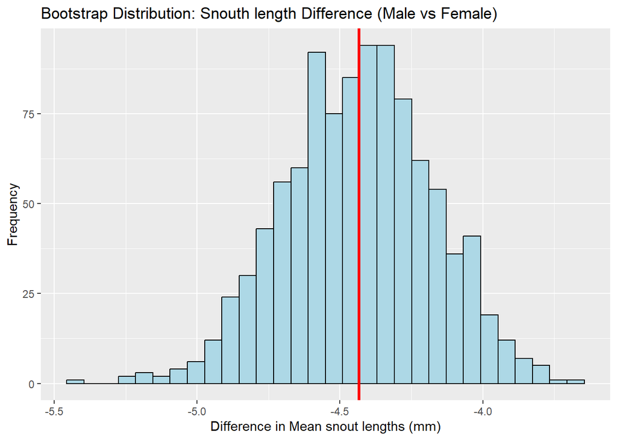

```r
# Convert to dataframe
boot_mean_snout_len_dist <- data.frame(diff_len = boot_mean_snout_len)

#Plot bootstrap Distribution Histogram
ggplot(boot_mean_snout_len_dist, aes(x = diff_len))  +
    geom_histogram(bins = 30, fill = "lightblue", color = "black") +
    geom_vline(xintercept = mean(boot_mean_snout_len),
             color = "red", linewidth = 1.2) +
  labs(
    title = "Bootstrap Distribution: Snouth length Difference (Male vs Female)",
    x = "Difference in Mean snout lengths (mm)",
    y = "Frequency"
  )
```

```r
 #Comparative Table
comparative_table_for_mean_len <- data.frame(
  Statistic = c("Mean", "Median", "Standard Deviation"),
  Male = c(
    mean(male_snout_len),
    median(male_snout_len),
    sd(male_snout_len)),
  Female = c(
    mean(female_snout_len),
    median(female_snout_len),
    sd(female_snout_len)
  ))

# Print table
print(comparative_table_for_mean_len)
```

```
##            Statistic      Male    Female
## 1               Mean 51.722222 56.160000
## 2             Median 52.000000 57.000000
## 3 Standard Deviation  3.756967  3.373414
```

The bootstrap distribution for the difference in mean snout-vent length in males vs females is centered at approximately -4.5 mm. Since the entire distribution is well below zero, we can conclude that there is a statistically significant difference in the size of snout-vent lengths between the sexes in this population.

# Generate Bootstrap Distribution Histogram and Comparative Statistics Table for Bootstrap estimate for mean Body temperatures (Gravid vs Non-Gravid)

The body temperature bootstrap distribution allows us to evaluate the thermoregulatory behavior of female lizards. The difference in means can be analyzed to infer whether reproductive status leads to changes in body temperature.

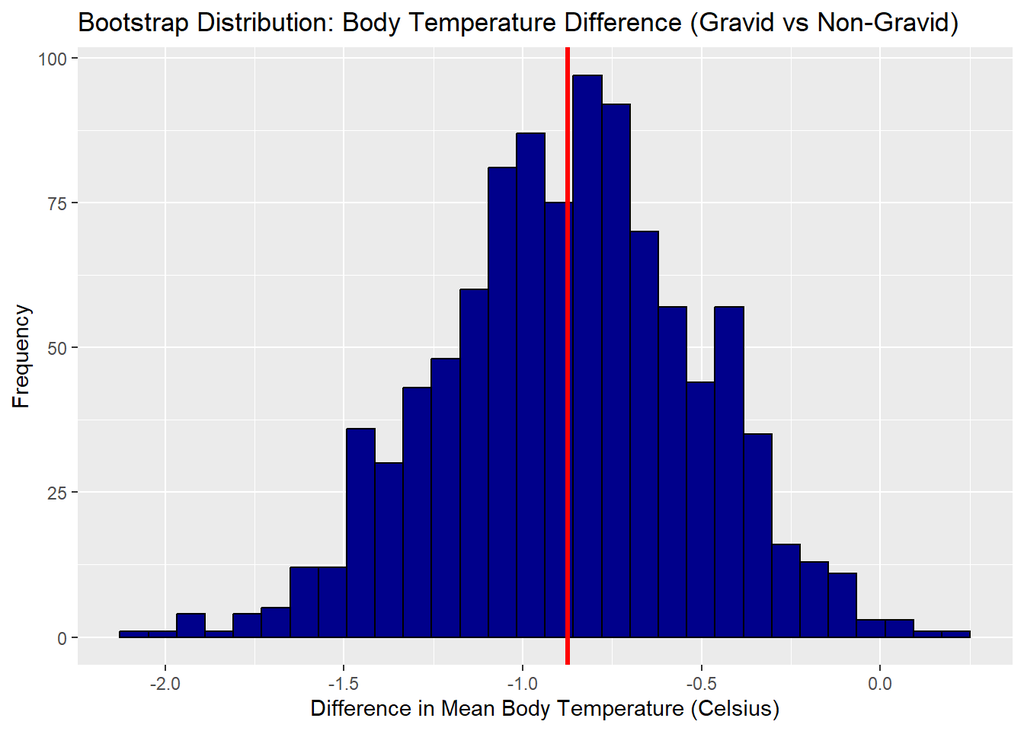

```r
# Convert to dataframe
boot_mean_body_temp_dist <- data.frame(diff_temp = boot_mean_body_temp)

#Plot bootstrap Distribution Histogram
ggplot(boot_mean_body_temp_dist, aes(x = diff_temp))  +
    geom_histogram(bins = 30, fill = "darkblue", color = "black")+
    geom_vline(xintercept = mean(boot_mean_body_temp),
             color = "red", linewidth = 1.2) +
  labs(
    title = "Bootstrap Distribution: Body Temperature Difference (Gravid vs Non-Gravid)",
    x = "Difference in Mean Body Temperature (Celsius)",
    y = "Frequency"
  )
```

```r
 #Comparative Table
comparative_table_for_mean_body_temp <- data.frame(
  Statistic = c("Mean", "Median", "Standard Deviation"),
  Gravid = c(
    mean(f_gravid_btemp),
    median(f_gravid_btemp),
    sd(f_gravid_btemp)),
  Nongravid = c(
    mean(f_nongravid_btemp),
    median(f_nongravid_btemp),
    sd(f_nongravid_btemp)
  ))

# Print table
print(comparative_table_for_mean_body_temp)
```

```
##            Statistic    Gravid Nongravid
## 1               Mean 35.144000  36.02960
## 2             Median 35.800000  36.30000
## 3 Standard Deviation  3.155446   2.37789
```

The comparison of body temperatures between gravid and non-gravid females shows a bootstrap distribution centered near -0.9°C. The large majority of the distribution is below zero and negative. This provides evidence to suggest that reproductive status does influence thermoregulation in this species.

# AI Declaration

The authors used Gemini and ChatGPT for technical troubleshooting/debugging R error messages and Git version control conflicts. These tools were also used to generate ideas for test cases, provide R grammar suggestions and offer feedback on formatting.The authors reviewed and verified any AI-suggested logic and feedback.

# Bibliography

Chang, Winston, Joe Cheng, JJ Allaire, Carson Sievert, Barret Schloerke, Garrick Aden-Buie, Yihui Xie, et al. 2025. *Shiny: Web Application Framework for r*. https://doi.org/10.32614/CRAN.package.shiny.

Gainsbury, Alison. 2021. “Size, Sex, Reproductive Status and Body Temperature Dataset.” Dryad. https://doi.org/10.5061/dryad.dbrv15f00.

Google. 2026. “Gemini(feb 24 Version).” Large language model. https://gemini.google.com/.

OpenAI. 2026. “ChatGPT(GPT-4/5-Based Large Language Model).” https://chat.openai.com/.

R Core Team. 2025. *R: A Language and Environment for Statistical Computing*. Vienna, Austria: R Foundation for Statistical Computing. https://www.R-project.org/.

Rizzo, Maria L. 2019. *Statistical Computing with R*. Second. Chapman; Hall/CRC. https://doi.org/10.1201/9780429192760.